# 1. Making Necessary Study

```python
import pandas as pd
import numpy as np
import seaborn as sns
from matplotlib import pyplot as plt
%matplotlib inline
```

```python
df=pd.read_csv("Bank_Personal_Loan_Modelling.csv")
```

```python
df.info()
```

```
<class 'pandas.core.frame.DataFrame'>
RangeIndex: 5000 entries, 0 to 4999
Data columns (total 14 columns):
 #   Column              Non-Null Count  Dtype
---  ------              --------------  -----
 0   ID                  5000 non-null   int64
 1   Age                 5000 non-null   int64
 2   Experience          5000 non-null   int64
 3   Income              5000 non-null   int64
 4   ZIP Code            5000 non-null   int64
 5   Family              5000 non-null   int64
 6   CCAvg               5000 non-null   float64
 7   Education           5000 non-null   int64
 8   Mortgage            5000 non-null   int64
 9   Personal Loan       5000 non-null   int64
 10  Securities Account  5000 non-null   int64
 11  CD Account          5000 non-null   int64
 12  Online              5000 non-null   int64
 13  CreditCard          5000 non-null   int64
dtypes: float64(1), int64(13)
memory usage: 547.0 KB
```

```python
df.shape # shape of the data : It has 5000 rows and 14 Columns
```

```
(5000, 14)
```

```python
df.index #looks like the index is ID and it is unique
```

```
RangeIndex(start=0, stop=5000, step=1)
```

```python
df.describe()
```

|  | ID | Age | Experience | Income | ZIP Code | Family | CCAvg | Education | Mortgage | Personal Loan | Securities Account | CD Account | Online | CreditCard |
| --- | --- | --- | --- | --- | --- | --- | --- | --- | --- | --- | --- | --- | --- | --- |
| count | 5000.000000 | 5000.000000 | 5000.000000 | 5000.000000 | 5000.000000 | 5000.000000 | 5000.000000 | 5000.000000 | 5000.000000 | 5000.000000 | 5000.000000 | 5000.00000 | 5000.000000 | 5000.000000 |
| mean | 2500.500000 | 45.338400 | 20.104600 | 73.774200 | 93152.503000 | 2.396400 | 1.937938 | 1.881000 | 56.498800 | 0.096000 | 0.104400 | 0.06040 | 0.596800 | 0.294000 |
| std | 1443.520003 | 11.463166 | 11.467954 | 46.033729 | 2121.852197 | 1.147663 | 1.747659 | 0.839869 | 101.713802 | 0.294621 | 0.305809 | 0.23825 | 0.490589 | 0.455637 |
| min | 1.000000 | 23.000000 | -3.000000 | 8.000000 | 9307.000000 | 1.000000 | 0.000000 | 1.000000 | 0.000000 | 0.000000 | 0.000000 | 0.00000 | 0.000000 | 0.000000 |
| 25% | 1250.750000 | 35.000000 | 10.000000 | 39.000000 | 91911.000000 | 1.000000 | 0.700000 | 1.000000 | 0.000000 | 0.000000 | 0.000000 | 0.00000 | 0.000000 | 0.000000 |
| 50% | 2500.500000 | 45.000000 | 20.000000 | 64.000000 | 93437.000000 | 2.000000 | 1.500000 | 2.000000 | 0.000000 | 0.000000 | 0.000000 | 0.00000 | 1.000000 | 0.000000 |
| 75% | 3750.250000 | 55.000000 | 30.000000 | 98.000000 | 94608.000000 | 3.000000 | 2.500000 | 3.000000 | 101.000000 | 0.000000 | 0.000000 | 0.00000 | 1.000000 | 1.000000 |
| max | 5000.000000 | 67.000000 | 43.000000 | 224.000000 | 96651.000000 | 4.000000 | 10.000000 | 3.000000 | 635.000000 | 1.000000 | 1.000000 | 1.00000 | 1.000000 | 1.000000 |

# 2. Column Description - Observations and Findings

Age :

1. Mean and Median approximately match on the Age Criteria and hence there is not much skew in that Column.
2. Standard Deviation is Huge, implying that age is spread out. Its correlation with other Quantities is of crucial importance.

Experience :

1. We can see here that Age has -3 Years of Experience as its minimum, so its a bad anamoly in the data. That is not possible so we have to see the careful look.
2. Experience has mean and median matched, so there is not much skew in the data.
3. It has huge standard deviation too. That observation implies that the correlation with other Parameters need to be carefully observed.
4. Experience of 43 years as a maximum seems to correspond to the maximum age of 67 years, but it should be dealt with proper suspicion because of the retirement age.

Income (in Dollars Per Year):

1. Mean Income seems to be 73K and median is 64K, which is closer, but the maximum is more than double of the mean and also more than double of the 75 % indicating that there are some ridiculous outliers
2. Standard deviation is riddiculously huge implying so much income inequality that we need to be careful with outliers. Can be analyzed using boxplot.

ZIP Code :

1. This column has no relevance whatsoever regarding anything else.
2. Correlation needs to be made with other Parameters.

Family :

CCAvg (in Dollars Per Month):

Education :

Mortgage (in Dollars):

1. It seems to be Highly skewed data. The skew needs to observed because the mean is nowhere near the median and the maximum value is riddiculously high.
2. Standard Deviation seems more like outlier than actual data. Boxplot or distplot needs to be done to make sure that there are very few outliers or a large number of outliers.

Personal Loan, Security Account, Online, CreditCard :

1. Since these are Binary values there is nothing we can see, except take the count plot and see.

```python
df.head()
```

|  | ID | Age | Experience | Income | ZIP Code | Family | CCAvg | Education | Mortgage | Personal Loan | Securities Account | CD Account | Online | CreditCard |
| --- | --- | --- | --- | --- | --- | --- | --- | --- | --- | --- | --- | --- | --- | --- |
| 0 | 1 | 25 | 1 | 49 | 91107 | 4 | 1.6 | 1 | 0 | 0 | 1 | 0 | 0 | 0 |
| 1 | 2 | 45 | 19 | 34 | 90089 | 3 | 1.5 | 1 | 0 | 0 | 1 | 0 | 0 | 0 |
| 2 | 3 | 39 | 15 | 11 | 94720 | 1 | 1.0 | 1 | 0 | 0 | 0 | 0 | 0 | 0 |
| 3 | 4 | 35 | 9 | 100 | 94112 | 1 | 2.7 | 2 | 0 | 0 | 0 | 0 | 0 | 0 |
| 4 | 5 | 35 | 8 | 45 | 91330 | 4 | 1.0 | 2 | 0 | 0 | 0 | 0 | 0 | 1 |

```python
#df[df.isna()].count()
df.isna().values.any() #Can be used alternatively
```

```
False
```

Conclusion : Seems like There are no missing entries

```python
df.isnull().values.any()
```

```
False
```

Conclusion : There are no Null Values too.

```python
df.dtypes # Checking Various Datatypes of the Columns
```

```
ID                      int64
Age                     int64
Experience              int64
Income                  int64
ZIP Code                int64
Family                  int64
CCAvg                 float64
Education               int64
Mortgage                int64
Personal Loan           int64
Securities Account      int64
CD Account              int64
Online                  int64
CreditCard              int64
dtype: object
```

```python
df["ID"].is_unique #Checking to see if ID is unique and can be used for Indexing extensively
```

```
True
```

Conclusion : There are no Null Values. So, we can use it for Indexing and analysis.

# Making Some EDA on the Data

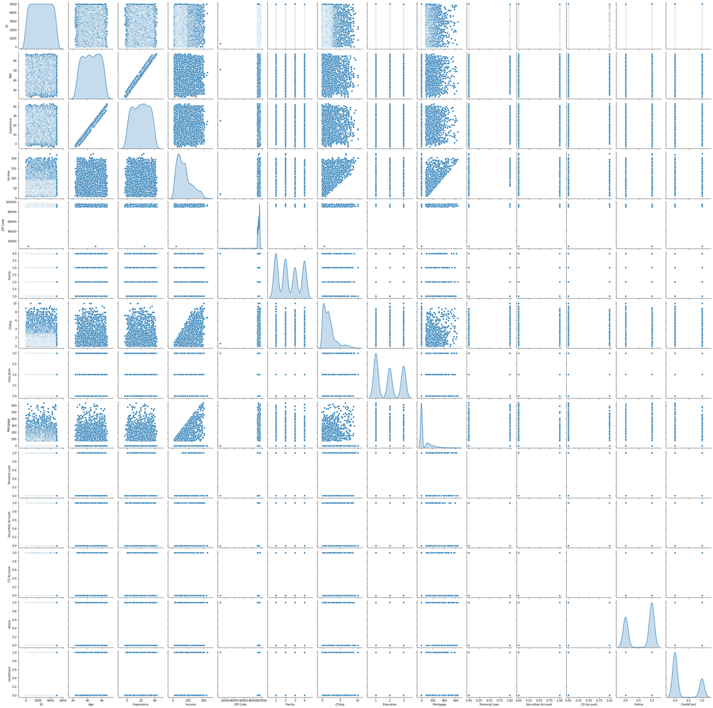

```python
#Distribution of personal loans can be done w.r.t all the columns of the
sns.pairplot(df,diag_kind='kde')
```

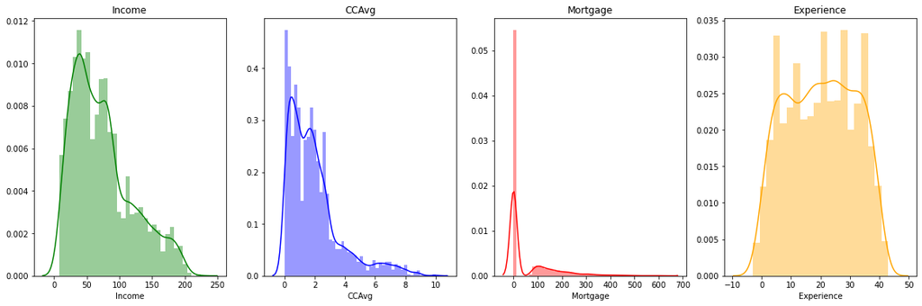

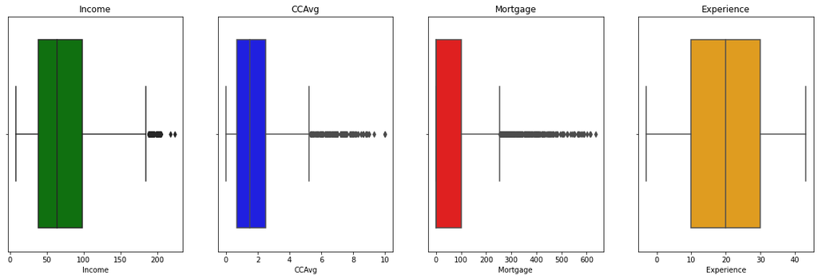

```python
#Checking for the Distribution Anamolies for some Noted Columns

plt.figure(figsize=(20,6))

# checking "Income" for Distribution Anamolies

plt.subplot(1, 4, 1)
plt.title('Income')
sns.distplot(df['Income'],color='green')

# Checking "CCAvg" for Distribution Anamolies

plt.subplot(1, 4, 2)
plt.title('CCAvg')
sns.distplot(df['CCAvg'],color='blue')

# Checking "Age" for Distribution Anamolies

plt.subplot(1, 4, 3)
plt.title('Mortgage')
sns.distplot(df['Mortgage'],color='red')

# Checking "Experience" for Distribution Anamolies

plt.subplot(1, 4, 4)
plt.title('Experience')
sns.distplot(df['Experience'],color='orange')


# Checking the Same above with Boxplots to value the Significance of Outliers

plt.figure(figsize=(20,6))

# checking "Income" for Outlier Anamolies

plt.subplot(1, 4, 1)
plt.title('Income')
sns.boxplot(df['Income'],color='green')

# Checking "CCAvg" for Outlier Anamolies

plt.subplot(1, 4, 2)
plt.title('CCAvg')
sns.boxplot(df['CCAvg'],color='blue')

# Checking "Age" for Outlier Anamolies

plt.subplot(1, 4, 3)
plt.title('Mortgage')
sns.boxplot(df['Mortgage'],color='red')

# Checking "Experience" for Outlier Anamolies

plt.subplot(1, 4, 4)
plt.title('Experience')
sns.boxplot(df['Experience'],color='orange')
```

Conclusion : Looks like the Experience Column has nothing to do and not much activity going on. Leaving it now for future analysis.

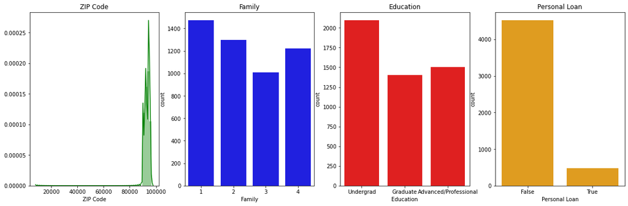

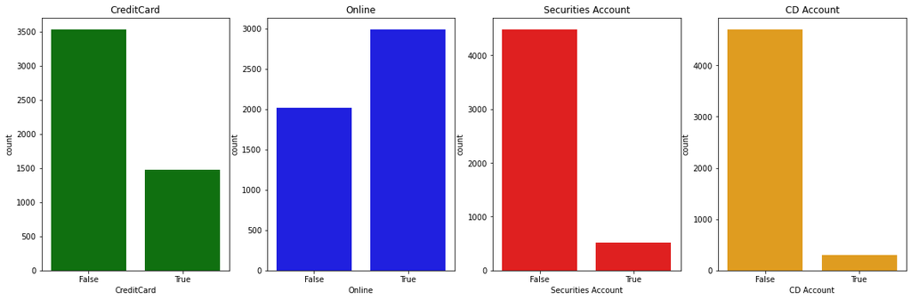

```python
# Separating columns that doesn't show much and checking for their anamolies through count plots
df_count_plots=df[["ZIP Code","Family","Education","Personal Loan","CreditCard","Online","Securities Account","CD Account"]]

#Setting up a figuresize
plt.figure(figsize=(20,6))

plt.subplot(1, 4, 1)
plt.title('ZIP Code')
sns.distplot(df_count_plots['ZIP Code'],color='green')


plt.subplot(1, 4, 2)
plt.title('Family')
sns.countplot(df_count_plots['Family'],color='blue')


plt.subplot(1, 4, 3)
plt.title('Education')
sns.countplot(df_count_plots['Education'].replace({1:"Undergrad",2:"Graduate",3:"Advanced/Professional"}),color='red')


plt.subplot(1, 4, 4)
plt.title('Personal Loan')
sns.countplot(df_count_plots['Personal Loan'].replace({0:False,1:True}),color='orange')


# Second Row of Figures
plt.figure(figsize=(20,6))

plt.subplot(1, 4, 1)
plt.title('CreditCard')
sns.countplot(df_count_plots['CreditCard'].replace({0:False,1:True}),color='green')


plt.subplot(1, 4, 2)
plt.title('Online')
sns.countplot(df_count_plots['Online'].replace({0:False,1:True}),color='blue')


plt.subplot(1, 4, 3)
plt.title('Securities Account')
sns.countplot(df_count_plots['Securities Account'].replace({0:False,1:True}),color='red')


plt.subplot(1, 4, 4)
plt.title('CD Account')
sns.countplot(df_count_plots['CD Account'].replace({0:False,1:True}),color='orange')
```

```python
df_other = df.drop(df_count_plots.columns,axis=1)
print(df_other.skew)
```

[output not shown]

Not Much Information from here

# Eliminating Outliers

```python
#Extreme Values of the Income are eliminated from the Data
Q1=df["Income"].quantile(0.25)
Q3=df["Income"].quantile(0.75)
IQR = Q3 - Q1
condition_for_outliers = (df["Income"] < (Q1 - 1.5 * IQR)) | (df["Income"] > (Q3 + 1.5 * IQR))
#print(condition_for_outliers)
df=df.drop(df[condition_for_outliers].index)
df
```

|  | ID | Age | Experience | Income | ZIP Code | Family | CCAvg | Education | Mortgage | Personal Loan | Securities Account | CD Account | Online | CreditCard |
| --- | --- | --- | --- | --- | --- | --- | --- | --- | --- | --- | --- | --- | --- | --- |
| 0 | 1 | 25 | 1 | 49 | 91107 | 4 | 1.6 | 1 | 0 | 0 | 1 | 0 | 0 | 0 |
| 1 | 2 | 45 | 19 | 34 | 90089 | 3 | 1.5 | 1 | 0 | 0 | 1 | 0 | 0 | 0 |
| 2 | 3 | 39 | 15 | 11 | 94720 | 1 | 1.0 | 1 | 0 | 0 | 0 | 0 | 0 | 0 |
| 3 | 4 | 35 | 9 | 100 | 94112 | 1 | 2.7 | 2 | 0 | 0 | 0 | 0 | 0 | 0 |
| 4 | 5 | 35 | 8 | 45 | 91330 | 4 | 1.0 | 2 | 0 | 0 | 0 | 0 | 0 | 1 |
| ... | ... | ... | ... | ... | ... | ... | ... | ... | ... | ... | ... | ... | ... | ... |
| 4995 | 4996 | 29 | 3 | 40 | 92697 | 1 | 1.9 | 3 | 0 | 0 | 0 | 0 | 1 | 0 |
| 4996 | 4997 | 30 | 4 | 15 | 92037 | 4 | 0.4 | 1 | 85 | 0 | 0 | 0 | 1 | 0 |
| 4997 | 4998 | 63 | 39 | 24 | 93023 | 2 | 0.3 | 3 | 0 | 0 | 0 | 0 | 0 | 0 |
| 4998 | 4999 | 65 | 40 | 49 | 90034 | 3 | 0.5 | 2 | 0 | 0 | 0 | 0 | 1 | 0 |
| 4999 | 5000 | 28 | 4 | 83 | 92612 | 3 | 0.8 | 1 | 0 | 0 | 0 | 0 | 1 | 1 |

4904 rows × 14 columns

We Can do the same with other columns too, but it is not mentioned in the objectives (since its not a Logistic Variable).

# Correlation Matrix for Conclusions to be drawn

```python
correlation=df.corr()
df.corr() #printing the correlation values reflecting above graphs
```

|  | ID | Age | Experience | Income | ZIP Code | Family | CCAvg | Education | Mortgage | Personal Loan | Securities Account | CD Account | Online | CreditCard |
| --- | --- | --- | --- | --- | --- | --- | --- | --- | --- | --- | --- | --- | --- | --- |
| ID | 1.000000 | -0.008820 | -0.008533 | -0.017633 | 0.011572 | -0.014864 | -0.028292 | 0.025495 | -0.007122 | -0.017680 | -0.016832 | -0.004334 | -0.005279 | 0.017950 |
| Age | -0.008820 | 1.000000 | 0.994210 | -0.047833 | -0.030166 | -0.050039 | -0.046929 | 0.037731 | -0.011406 | -0.009815 | -0.000961 | 0.005482 | 0.017191 | 0.006734 |
| Experience | -0.008533 | 0.994210 | 1.000000 | -0.039203 | -0.029274 | -0.056152 | -0.044993 | 0.009497 | -0.009981 | -0.009139 | -0.001799 | 0.007491 | 0.016977 | 0.007876 |
| Income | -0.017633 | -0.047833 | -0.039203 | 1.000000 | -0.014318 | -0.153546 | 0.629173 | -0.185269 | 0.189925 | 0.498517 | -0.000927 | 0.170725 | 0.014391 | 0.001180 |
| ZIP Code | 0.011572 | -0.030166 | -0.029274 | -0.014318 | 1.000000 | 0.011761 | -0.004462 | -0.017241 | 0.008188 | 0.002959 | 0.004445 | 0.025240 | 0.018034 | 0.006698 |
| Family | -0.014864 | -0.050039 | -0.056152 | -0.153546 | 0.011761 | 1.000000 | -0.101702 | 0.058895 | -0.023911 | 0.058669 | 0.017479 | 0.009833 | 0.010624 | 0.009120 |
| CCAvg | -0.028292 | -0.046929 | -0.044993 | 0.629173 | -0.004462 | -0.101702 | 1.000000 | -0.132835 | 0.102024 | 0.365428 | 0.017026 | 0.140655 | -0.001901 | -0.003860 |
| Education | 0.025495 | 0.037731 | 0.009497 | -0.185269 | -0.017241 | 0.058895 | -0.132835 | 1.000000 | -0.033316 | 0.123386 | -0.012407 | 0.007208 | -0.014890 | -0.010968 |
| Mortgage | -0.007122 | -0.011406 | -0.009981 | 0.189925 | 0.008188 | -0.023911 | 0.102024 | -0.033316 | 1.000000 | 0.128323 | -0.003731 | 0.085647 | -0.004192 | -0.005020 |
| Personal Loan | -0.017680 | -0.009815 | -0.009139 | 0.498517 | 0.002959 | 0.058669 | 0.365428 | 0.123386 | 0.128323 | 1.000000 | 0.021450 | 0.312514 | 0.008256 | 0.006179 |
| Securities Account | -0.016832 | -0.000961 | -0.001799 | -0.000927 | 0.004445 | 0.017479 | 0.017026 | -0.012407 | -0.003731 | 0.021450 | 1.000000 | 0.315416 | 0.009393 | -0.016309 |
| CD Account | -0.004334 | 0.005482 | 0.007491 | 0.170725 | 0.025240 | 0.009833 | 0.140655 | 0.007208 | 0.085647 | 0.312514 | 0.315416 | 1.000000 | 0.174407 | 0.279796 |
| Online | -0.005279 | 0.017191 | 0.016977 | 0.014391 | 0.018034 | 0.010624 | -0.001901 | -0.014890 | -0.004192 | 0.008256 | 0.009393 | 0.174407 | 1.000000 | 0.005318 |
| CreditCard | 0.017950 | 0.006734 | 0.007876 | 0.001180 | 0.006698 | 0.009120 | -0.003860 | -0.010968 | -0.005020 | 0.006179 | -0.016309 | 0.279796 | 0.005318 | 1.000000 |

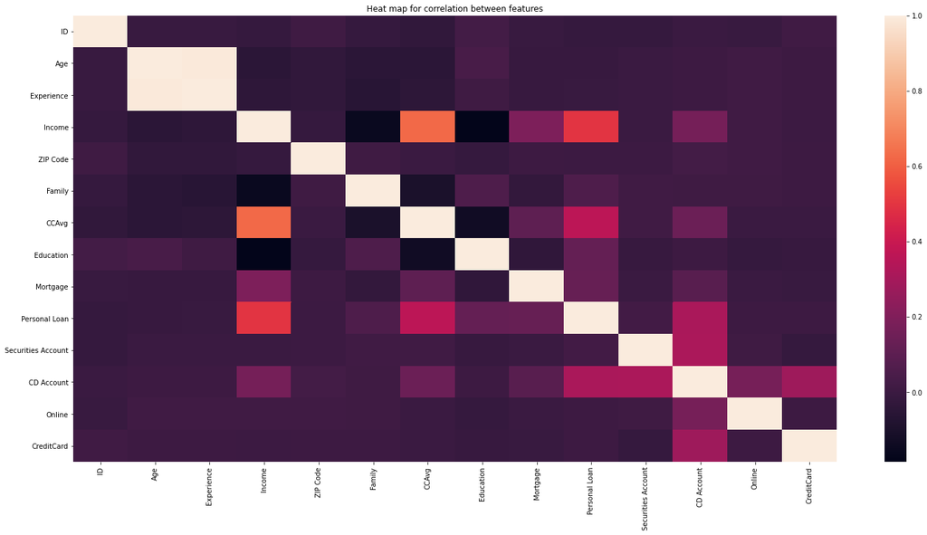

```python
plt.figure(figsize=(25,12))
plt.title("Heat map for correlation between features")
sns.heatmap(correlation)
plt.show()
```

# Observations Made from Correlation Matrix

```python
columns_list=[]
correlation_value=0.5 # You can change the value here based on the user Choice and the whole program will result in appropriate ways


def check_for_correlationratio(column,column2,correlation):
    if correlation[column][column2] > correlation_value: #You can change the value here with user input
        return (column1,column2)
    else:
        return
def check_for_repetitions(columns_list):
    columns_list=list(filter(None,columns_list))
    for tuple_element1 in columns_list:
        for tuple_element2 in columns_list:
            if tuple_element1[0]==tuple_element2[1] and tuple_element2[1]==tuple_element1[0]:
                columns_list=columns_list.remove(tuple_element2)
    return columns_list


for column1 in correlation.columns:
    for column2 in correlation.columns:
        if column1 == column2:
            pass
        else:
            #print(column1)
            #print(column2)
            #print (correlation[column1][column2])

            #columns_list=check_for_repetitions(columns_list)
            if correlation[column1][column2] > correlation_value:
                columns_list.append((column1,column2))
                #print(correlation[column1][column2])
                #print(columns_list)

print ("The following pairs of variables have Correlation greater than {} \n".format(correlation_value))
print (columns_list)
```

```
The following pairs of variables have Correlation greater than 0.5

[('Age', 'Experience'), ('Experience', 'Age'), ('Income', 'CCAvg'), ('CCAvg', 'Income')]
```

```python
#Using this to remove duplicated entries of correlated Quantities
for tuple1 in columns_list:
    #print (tuple1)
    for tuple2 in columns_list:
        #print (tuple2)
        if tuple1[0]==tuple2[1]:
            columns_list.remove(tuple2)
#print(columns_list)
#further processing to create a clean iterable list of varaibles
Model_columns=[]
for value1,value2 in columns_list:
    Model_columns.append(value1)
    Model_columns.append(value2)
Model_columns=list(set(Model_columns))
print(Model_columns)
```

```
['Income', 'Age', 'Experience', 'CCAvg']
```

```python
#Creating a new Dataframe for these variables to create models if any based on correlation observed
df_new=pd.DataFrame(df[Model_columns])
df_new
```

|  | Income | Age | Experience | CCAvg |
| --- | --- | --- | --- | --- |
| 0 | 49 | 25 | 1 | 1.6 |
| 1 | 34 | 45 | 19 | 1.5 |
| 2 | 11 | 39 | 15 | 1.0 |
| 3 | 100 | 35 | 9 | 2.7 |
| 4 | 45 | 35 | 8 | 1.0 |
| ... | ... | ... | ... | ... |
| 4995 | 40 | 29 | 3 | 1.9 |
| 4996 | 15 | 30 | 4 | 0.4 |
| 4997 | 24 | 63 | 39 | 0.3 |
| 4998 | 49 | 65 | 40 | 0.5 |
| 4999 | 83 | 28 | 4 | 0.8 |

4904 rows × 4 columns

[figure not shown]

[figure not shown]

[figure not shown]

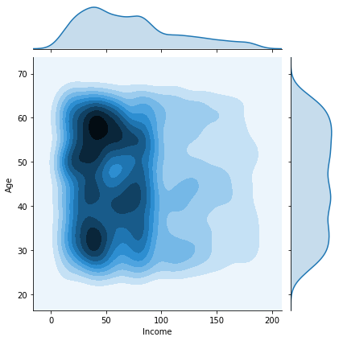

[figure not shown]

[figure not shown]

[figure not shown]

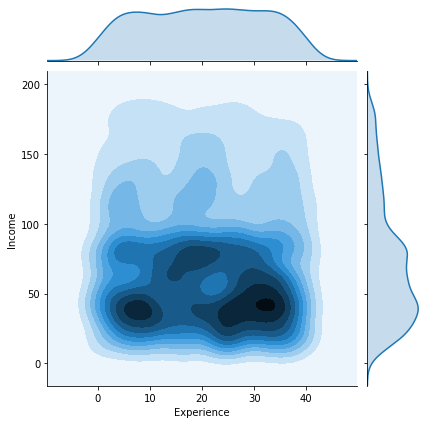

```python
#Setting up a figuresize
plt.figure(figsize=(20,6))

plt.subplot(1, 3, 1)
plt.title('Age Vs CCAvg')
sns.jointplot(x=df_new['CCAvg'],y=df_new["Age"],kind="kde")


plt.subplot(1, 3, 2)
plt.title('Age Vs Experience')
sns.jointplot(x=df_new['Experience'],y=df_new['Age'],kind="kde")


plt.subplot(1, 3, 3)
plt.title('Age Vs Income')
sns.jointplot(x=df_new['Income'],y=df_new['Age'],kind="kde")

plt.figure(figsize=(20,6))

plt.subplot(1, 3, 1)
plt.title('CCAvg Vs Experience')
sns.jointplot(x=df_new['Experience'],y=df_new['CCAvg'],kind="kde")

plt.subplot(1, 3, 2)
plt.title('CCAvg Vs Income')
sns.jointplot(x=df_new['Income'],y=df_new['CCAvg'],kind="kde")

plt.subplot(1, 3, 3)
plt.title('Experience Vs Income')
sns.jointplot(x=df_new["Experience"],y=df_new["Income"],kind="kde")
```

Some Example Individual Plots in case if the above cell didn't show up well.

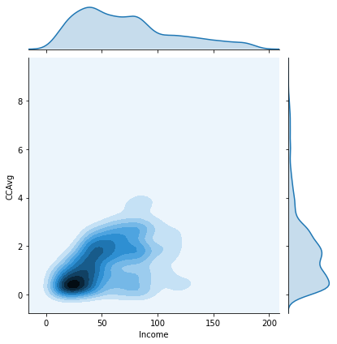

```python
sns.jointplot(x=df["Income"],y=df["CCAvg"], kind="kde")
```

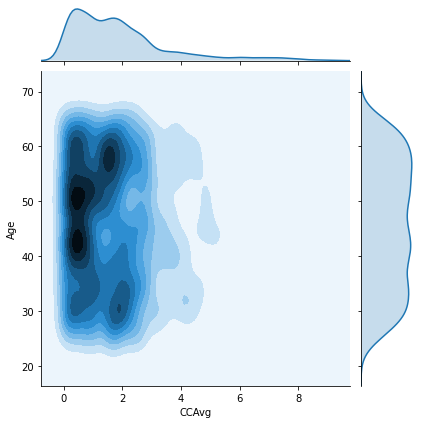

```python
sns.jointplot(y=df["Age"],x=df["CCAvg"], kind="kde")
```